# Statistical Principles and Experimental Design — Seminar 4 Inference & Significance Test

matthias.kuhn@tu-dresden.de

November 17, 2023 <sub>[a97b9ca]</sub>

**(solutions interspersed)**

## Weibull distribution

In the previous exercise, we described operating time in presence of constant failure rate (i.e., no ageing effect) via an exponential distribution. If there is an ageing effect (aka *wear-out*), though, the *Weibull* distribution is a better model. As we will see below, the Weibull distribution is a direct generalization of the exponential distribution.

The **probability density function (PDF)** of the two-parameter Weibull distribution is
$$f_{μ,k}(x) = \frac{k}{μ} · \big(\frac{x}{μ}\big)^{k-1} ·
\exp(-\big(\frac{x}{μ}\big)^k) \qquad \text{ for } x > 0 \text{ and 0
otherwise,}$$
where μ and $k$ are two parameters with $μ,k ∈ ℝ^+$. The so-called **scale parameter** $μ>0$ determines the time scale of the distribution, it can be interpreted as a (time) duration: it describes how long it takes so that the occurrence of a failure reaches a probability of 1-e<sup>-1</sup> = 63.21%. For a given Weibull distribution (with parameter $k$ fixed), the expected failure time increases linearly with μ. The other parameter, the so-called **shape parameter** $k>0$, determines *how* exactly the probability mass for failure is distributed over time. In particular, $k$ quantifies how the failure rate changes with time:

- $k>1$ for a wear-out effect (i.e. think of ageing)
- $k=1$ for constant failure rate
- $k<1$ for a wear-in effect (i.e. think of «infant mortality»)

Please solve the following tasks:

1. Show the correspondence of the exponential distribution and the Weibull distribution when the shape parameter $k$ is set to $k=1$.
2. Visualize the Weibull density function for the combinations of shape parameter *k* values in 0.25, 1 and 2 and scale parameter *μ* in 1 and 5 (six curves in total). Again, use `ggplot`’s `geom_function`. An advanced way to get the six curves together with a legend is to define a dataframe with all parameter combinations and to call `geom_function` repeatedly via `purrr::pmap`
3. The **cumulative distribution function (CDF)** is an alternative view on the distribution as a whole. It describes how much probability mass lies below or equal to a specified value. Differentiating the CDF yields the probability density function (PDF). Can you deduce the cumulative distribution function for the Weibull distribution, i.e., what does the function $F_X: t ↦ P(X ≤ t)$ look when $X$ is a random variable that follows a Weibull distribution?

**Solution**

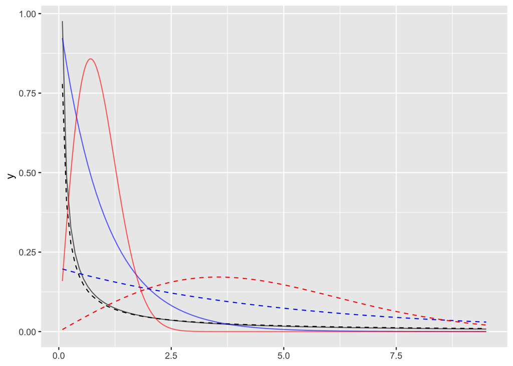

```r
library("ggplot2")

ggBase <- ggplot() + xlim(0.08, 9.5)

# repeated calls to geom_function
# colour and linetype are specified manually
# hence, no legend is added by ggplot automatically
# legends in ggplot really require you to set a mapping
ggBase +
  geom_function(fun = dweibull, args = list(shape = 0.25, scale = 1), alpha = .6, col = "black") +
  geom_function(fun = dweibull, args = list(shape = 0.25, scale = 5), linetype = "dashed", col = "black") +
  geom_function(fun = dweibull, args = list(shape = 1, scale = 1), alpha = .6, col = "blue") +
  geom_function(fun = dweibull, args = list(shape = 1, scale = 5), linetype = "dashed", col = "blue") +
  geom_function(fun = dweibull, args = list(shape = 2, scale = 1), alpha = .6, col = "red", n=1001) +
  geom_function(fun = dweibull, args = list(shape = 2, scale = 5), linetype = "dashed", col = "red")
```

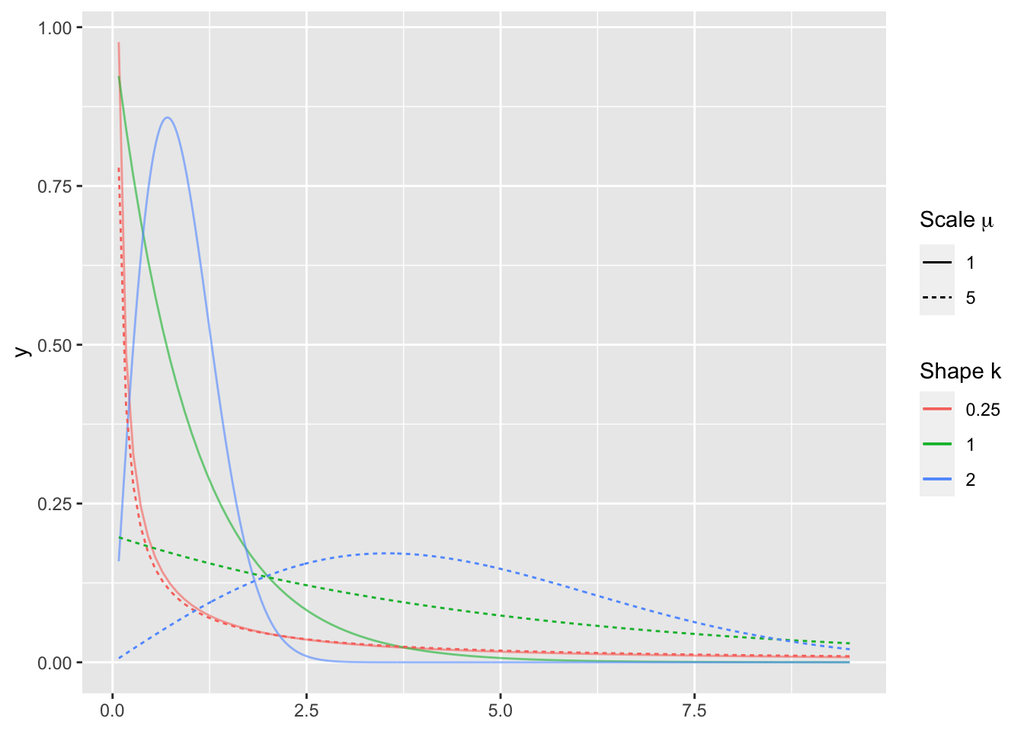

```r
# advanced way to plot multiple functions with legend
library("purrr") ## for pmap
pdata <- expand.grid(shape = c(0.25, 1, 2), scale = c(1,5)) ## parameter data as own dataframe

ggBase +
  # pmap to apply geom_function on every row of pdata:
  # .x = value of 1st column and .y = value of 2nd column
  purrr::pmap(pdata,
              # mapping: colour and linetype come from the provided data frame pdata
              # as.character() to relay parameters as discrete values.
              # This gives different colours (and not colour gradient)
              .f = ~geom_function(mapping = aes(col = as.character(.x), linetype = as.character(.y)),
                                  fun = dweibull, args = list(shape = .x, scale = .y),
                                  # alpha= and n=: fine-tuning of the plot's appearance
                                  # booleans can be used as numerics: TRUE is 1 and FALSE is 0
                                  alpha = c(.6, 1)[1+(.y > 1)], n=c(101, 1001)[1+(.x>1)])) +
  labs(col = "Shape k", linetype = expression("Scale"~mu))
```

The plot is quite busy. Normally, in `ggplot2` you can add `facet_wrap` to a plot to disentangle the different lines and use multiple plot panes that are each labelled. Unfortunately, this is not easily used here with `geom_function`.

3. The cumulative distribution function F<sub>X</sub> is calculated as an improper integral of the density from -∞ to some $t ∈ ℝ$. In case of the Weibull density, we can directly write down the anti-derivative of the integrand:
   $$\begin{align}
   F_X(t) &:= \int_{-\infty}^t f_{μ,k}(x) dx \\
   &= \int_{0}^t \frac{k}{μ} · (\frac{x}{μ})^{k-1} ·
   \exp(-(\frac{x}{μ})^k) dx \\
   &= -\exp(-(\frac{x}{μ})^k)\,\Big|_{x=0}^{x=t} \\
   &= -\exp(-(\frac{t}{μ})^k) - (-\exp(-(\frac{0}{μ})^k)) \\
   &= 1 - \exp(-(\frac{t}{μ})^k)
   \end{align}$$
   From this equation it becomes evident why after a time duration of $t=μ$ we have a probability of $1-\exp(-1) =$ 63.21% for a failure, independently of the shape parameter $k$.

We use `ggplot2` to visualize the CDF for the three different shape parameters and scale µ = 5.

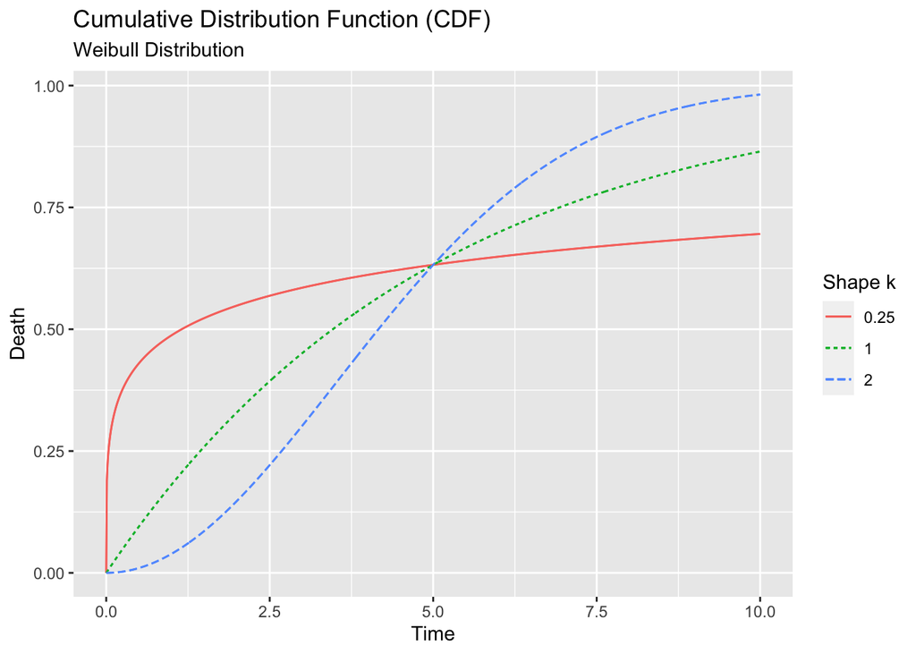

```r
ggplot() + xlim(0, 10) +
  purrr::map(.x = pdata$shape,
             .f = ~geom_function(mapping = aes(col = as.character(.x), linetype = as.character(.x)),
                                  fun = \(t, shape) 1-exp(-(t/5)^shape), args = list(shape = .x),
                                  n=1001)) +
  labs(title = "Cumulative Distribution Function (CDF)", subtitle = "Weibull Distribution",
       x = "Time", y = "Death",
       col = "Shape k", linetype = "Shape k")
```

## Survival Time after Brain tumour

Imagine that you follow up on a random sample of brain tumour patients that are treated with a specific type of chemotherapy. You record the 72 survival times of the patients in months since first diagnosis and you may assume that patient’s survival time is independent of each other. You collect the following survival time data:

| 0.03 | 0.96 | 1.87 | 3.11 | 4.02 | 6.02 | 6.57 | 12.29 | 13.55 | 16.33 | 20.61 | 40.99 |
| --- | --- | --- | --- | --- | --- | --- | --- | --- | --- | --- | --- |
| 0.37 | 1.06 | 1.97 | 3.41 | 4.84 | 6.04 | 7.30 | 12.36 | 14.36 | 16.35 | 22.05 | 43.18 |
| 0.43 | 1.12 | 2.39 | 3.50 | 5.06 | 6.11 | 11.44 | 12.51 | 14.44 | 17.22 | 22.66 | 44.81 |
| 0.59 | 1.32 | 2.53 | 3.78 | 5.23 | 6.12 | 11.97 | 12.60 | 14.79 | 18.46 | 26.34 | 45.64 |
| 0.82 | 1.35 | 2.71 | 3.80 | 5.64 | 6.17 | 11.99 | 13.08 | 15.64 | 19.59 | 27.42 | 66.21 |
| 0.85 | 1.80 | 2.94 | 3.80 | 5.89 | 6.35 | 12.20 | 13.38 | 15.93 | 20.05 | 34.70 | 73.73 |

You can take the values directly here from this document *or* find the data as an R-object in the material folder to this seminar and read it into your R-session using the built-in R-command `readRDS`.

### 1. Maximum Likelihood

Imagine that — based on previous studies — you can safely assume that the survival time can be modelled by a Weibull distribution and that the scale parameter μ of the Weibull distribution can be assumed to be *μ<sub>0</sub> = 10*.

1. What does the log-likelihood function look like for the **shape parameter** $k$ in this situation? Draw the curve.
2. Use a **numeric optimization** routine to find the maximum likelihood estimate $\hat k$. Use the R-function `optimize` for 1-dimensional optimization.
3. Use the likelihood function to come up with the **«⅛-likelihood interval» (⅛-LI)**: it is the interval that contains all shape parameters $k$ that have — compared to the MLE $\hat k$ — a likelihood ratio greater than ⅛. Parameter values within the ⅛-likelihood interval are those that are *«consistent with the observations»* in the sense that there are no parameter values $\tilde k$ that have *fairly strong evidence* in favour of $\tilde k$ *vis-à-vis* any $k$ ∈ ⅛-LI. By *«fairly strong evidence»*, we mean that the likelihood ratio exceeds 8, i.e., $\mathop{\mathrm{LR}}_{\tilde k, k} > 8$. The likelihood interval is an example of a interval estimator from a likelihood-based approach to statistics.
4. In view of the ⅛-LI, is the hypothesis of a constant «failure rate» consistent with the given observations?

**Solution**

1. With the scale parameter μ<sub>0</sub> = 10 being fixed and a sample of data given, the (log-)likelihood is a real-valued function with a single parameter $k$.
   $$\begin{align}
   L(k \,|\, \mathbf{x}, μ_0) &= \prod_{i=1}^n f_{μ_0,k}(x_i) =
   \prod_{i=1}^n \frac{k}{μ_0} · (\frac{x_i}{μ_0})^{k-1} ·
   \exp(-(\frac{x_i}{μ_0})^k) \\
   &= \frac{k^n}{μ_0^{kn}} ·\prod_{i=1}^n x_i^{k-1} ·
   \exp(-(\frac{x_i}{μ_0})^k) \\[2ex]
   l(k \,|\, \mathbf{x}, μ_0) &= n \log(k) - kn\log(μ_0) + (k-1) ·
   \sum_{i=1}^n \log(x_i) - \frac{1}{μ_0^k} \sum_{i=1}^n x_i^k
   \end{align}$$

First, we implement this function as an R-function. In the code, variable `survtime_bt` carries the vector of the observed survival times.

```r
# log-likelihood function
ll0 <- function(k)
  length(survtime_bt) * log(k) - length(survtime_bt) * k * log(10) +
  (k-1) * sum(log(survtime_bt)) - 10^(-k) * sum(survtime_bt^k)
```

This function works for individual values of $k$. But there is a subtle problem when we use whole vectors with more than one value for $k$: Generally, R is vectorized, meaning that R works element-wise on vectors. Normally, this just works fine but in our function we have the term `survtime_bt^k` which links the data vector `survtime_bt` and the shape parameter `k`.

In this instance, we need to explicitly **vectorize** our log-likelihood function to decouple the parameter `k` and the data vector.

```r
ll <- Vectorize(FUN=ll0)
```

We use `ggplot`’s `geom_function` to draw the log-likelihood for our given situation.

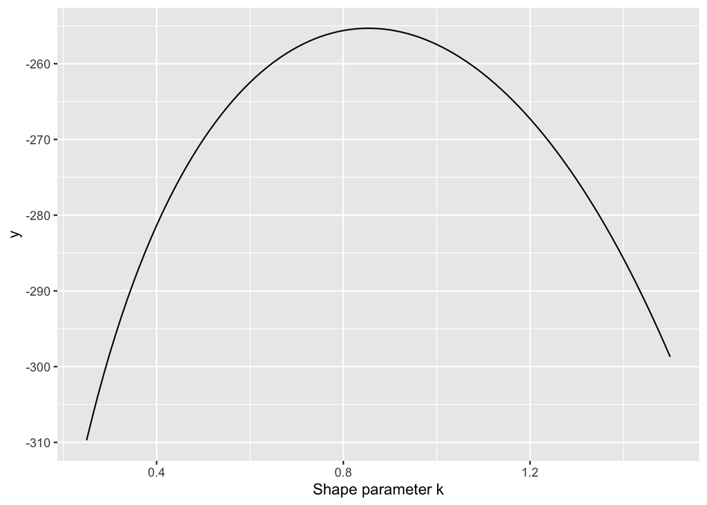

```r
ggplot() + xlim(0.25, 1.5) +
  geom_function(fun = ll) +
  labs(x = "Shape parameter k")
```

The quadratic shape of the log-likelihood is typical for «well-posed» ML-estimation problems.

2. We use R’s `optimize`-function to find the maximum for a one-parameter function.

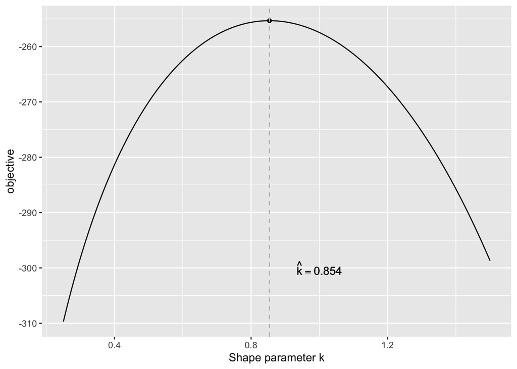

```r
# find MLE via optimize, mind to set `maximum = TRUE` as by default optimize will look for minimum
ll_opt <- optimize(ll, interval = c(0.01, 10), maximum = TRUE)
k_mle <- round(ll_opt$maximum, 3)

ggplot(data = data.frame(x=c(0.25, 1.5)), mapping = aes(x=x)) +
  geom_function(fun = ll) + labs(x = "Shape parameter k") +
  geom_point(data = as.data.frame(ll_opt), aes(x = maximum, y = objective)) +
  geom_vline(xintercept = ll_opt$maximum, col = "grey", linetype = "dashed") +
  annotate("text", label = bquote(hat(k) == .(k_mle)), x = 1, y = -300)
```

3. A likelihood *ratio* corresponds to a *difference* of log-likelihood values. As the log-likelihood function in this example is concave (it has a quadratic shape like $-x^2$) we need to look in the neighbourhood of the ML-estimate. Hence, we evaluate the log-likelihood function on a dense grid in the vicinity of the ML-estimate $\hat k = 0.854$. We retain those parameter values as elements of ⅛-LI that have a log-likelihood at most $\log(8)$ below the log-likelihood value of the ML-estimate.

```r
# 1/8-Likelihood interval around MLE
shapeParams <- seq(0.01, 2.5, by = 0.005)
shapeParamsLI <- shapeParams[which(ll(shapeParams) > ll_opt$objective - log(8) )]
LI_8 <- range(shapeParamsLI) # 1/8-LI boundaries
```

We get the ⅛-likelihood-interval (0.715-0.995) which by construction contains $\hat k$.

4. The shape parameter $k=1$ is **not** contained in the ⅛-LI. Hence, the assumption of constant failure rate (i.e. no ageing effect) is **not** consistent with the data.

### 2. Sampling distribution (Monte-Carlo simulation)

Show graphically the distribution of the estimate in the repeated sampling, for instance by means of a histogram, for each sample size $n$ separately. How would you describe its distribution. What can you say about its mean and variance depending on the sample size $n$?

**Solution**

We will generate many random samples and will repeatedly need to find the MLE for the shape parameter *k*. That’s why we first package the log-likelihood code into a function. We provide a factory function that — given the observed data — returns the log-likelihood function as an R-function.

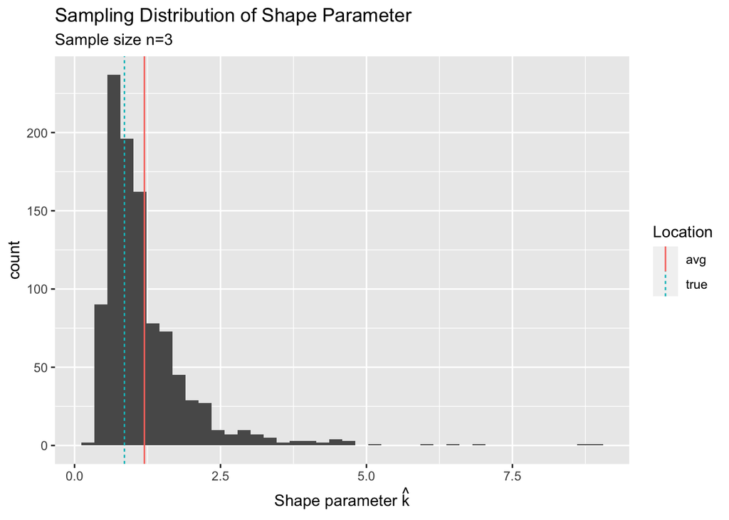

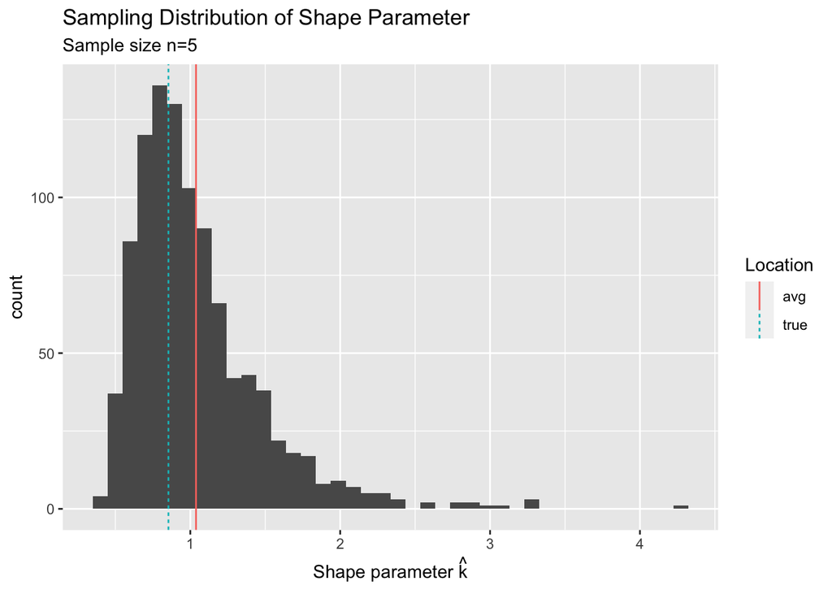

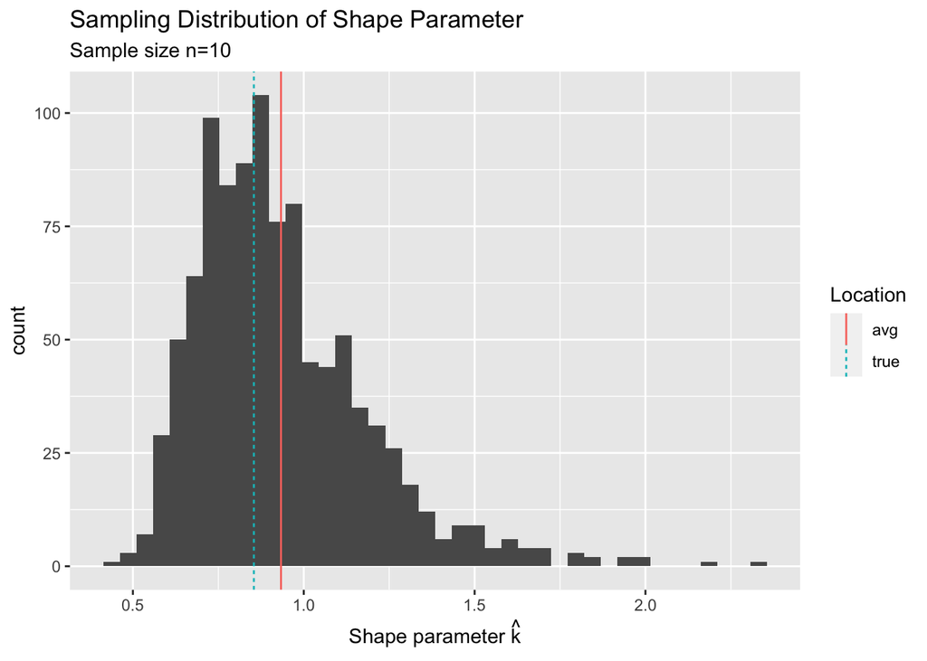

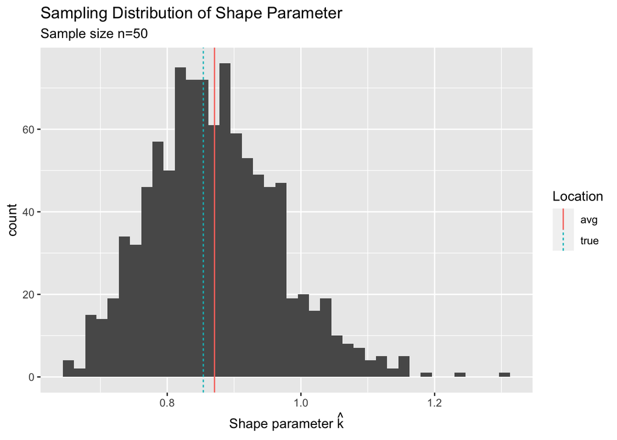

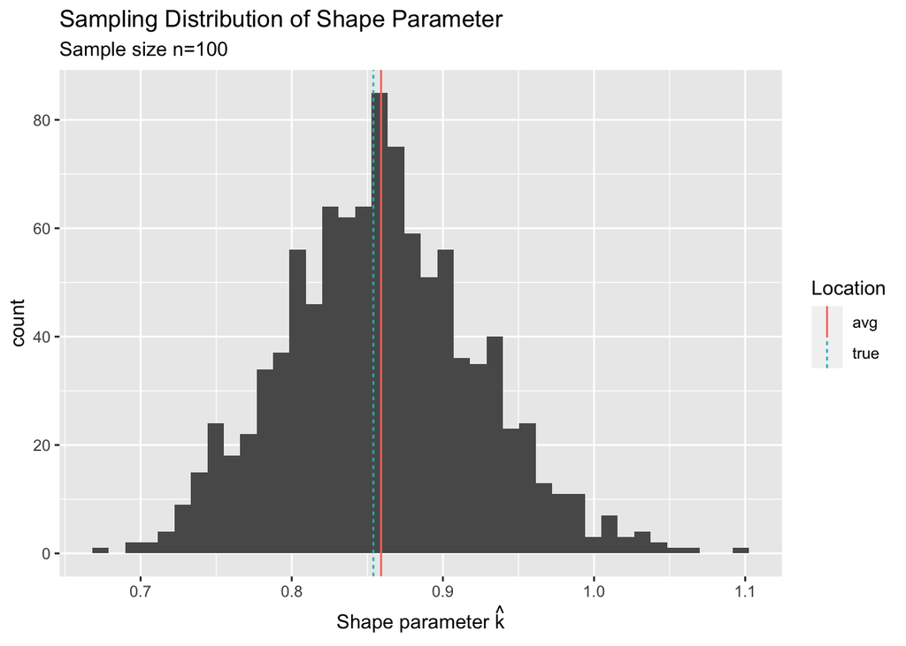

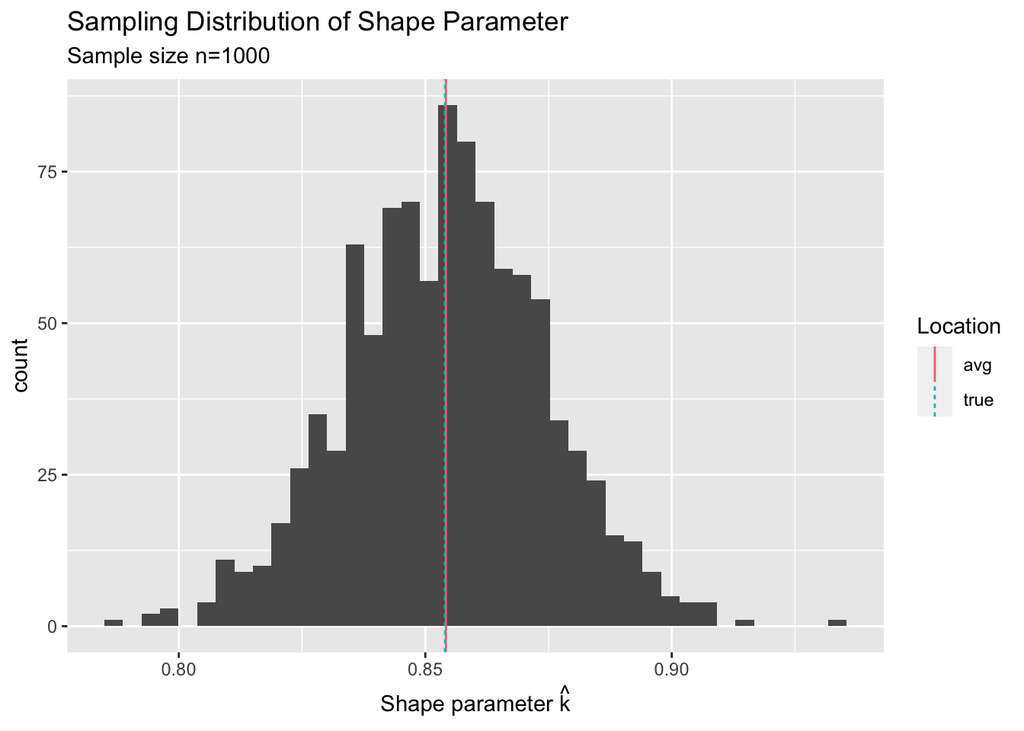

```r
# log-likelihood factory method
ll_weib_factory <- function(x){
  n <- length(x) # will be accessible to returned function
  function(k) n * log(k) - n * k * log(10) + (k-1) * sum(log(x)) - 10^(-k) * sum(x^k)
}

# function to do a monte-carlo simulation and repeatedly estimate shape parameter k
k_MLE_mc <- function(n=3, B=1001, shapeParam = k_mle, plotHist=TRUE){
  mcSimul <- replicate(n = B,
                       optimize(f = ll_weib_factory(rweibull(n = n,
                                                             shape = shapeParam,
                                                             scale = 10)),
                                interval = c(0.001, 10+shapeParam), maximum = TRUE)$maximum)

  # histograms of the estimates
  # also possible to use ggplot's geom_histogram function
  if (isTRUE(plotHist)){
    ggObj <- ggplot(data = data.frame(khat=mcSimul), mapping = aes(x = khat)) +
      geom_histogram(bins = 40) +
      geom_vline(data = # tribble to quickly write down a dataframe rowwise
                   tibble::tribble(~type, ~value,
                                   "avg", mean(mcSimul),
                                   "true", shapeParam),
                 mapping = aes(xintercept = value, col = type, linetype = type)) +
      labs(title = "Sampling Distribution of Shape Parameter",
           subtitle = sprintf("Sample size n=%d", n),
           x = expression(plain("Shape parameter ")*hat(k)),
           col = "Location", linetype = "Location")

    # print the ggplot object within a function to let it show up
    print(ggObj)
  }
  mcSimul
}


# purrr::walk to
# repeatedly call our function with varying sample size
purrr::walk(.x = c(3, 5, 10, 50, 100, 1000),
            .f = ~k_MLE_mc(n=.x, plotHist = TRUE))
```

The distribution of ML-estimates for shape parameter *k* changes with sample size *n*. Here, we use a high number of Monte-Carlo simulation runs (`B=1001`) to clearly see the form of the distribution. Its average is marked by the red vertical line. The true value of the shape parameter in the simulation ($\hat k =$ 0.85) is indicated in the plots via the vertical turquoise dotted line.

For small sample size *n* we see a **bias** upwards as the distribution is right-skewed. The bigger the sample size *n* in the Monte-Carlo simulation the closer the mean of the estimates of the shape parameter comes to the true value $\hat k =$ 0.85. We say, the estimator is *asymptotically unbiased*.

The **variance** reduces as well when *n* increases. (Mind how the scale of the x-axis changes when $n$ increases!) Together, asymptotic unbiasedness and asymptotically vanishing variance of the estimator means that its mean squared error (MSE) approaches 0 which implies *consistency* of the estimator.

For bigger sample sizes the right-skew vanishes and the distribution becomes more symmetric. Actually, the distribution looks more and more Gaussian («normal»). This is an example where the ML-estimator appears to be *asymptotically normally distributed*. It can be shown that this is a general property of the MLE as long as some «regularity conditions» on the likelihood function are met.

## Significance testing

We revisit the 1<sup>st</sup> exercise of this course about data exploration and descriptive statistics. A melanoma study presented by Fisher & van Belle (1993) had as main outcome of interest the mortality rate of white males in USA. A main question of the study was how the mortality rates compare for ocean vs non-ocean states.

1. Load the data `USmelanoma` as a dataframe into your R-session from the R-package `HSAUR3`. R’s `data` command loads data from a package via its `package=` option. Or: read in the CSV-file that you got in an earlier seminar.
2. To remind yourself: Create a boxplot that compares ocean and non-ocean states of the USA with respect to mortality rates. Use `geom_boxplot` from the `ggplot2`-package.
3. You might consider the Fisher & van Belle study data to be a random sample from two populations (of states), namely on the one hand from the homogeneous population of ocean states and on the other hand from the homogeneous population of non-ocean states. If you want to test if the location (e.g. the expected value) of the mortality rate is statistically significantly different between these two populations: what statistical significance test is appropriate, depending on the further assumptions you are willing to make with respect to the distribution of mortality rate within the respective population? Propose (at least) two approaches.
4. Do the statistical significance testing according to at least two proposed approaches and interpret the test results. Do you get different conclusions, depending on the chosen significance test?

**Solution**

1. We load the data `USmelanoma` from the package `HSAUR3`:

```r
data("USmelanoma", package = "HSAUR3")
head(USmelanoma)
```

```
##             mortality latitude longitude ocean
## Alabama           219     33.0      87.0   yes
## Arizona           160     34.5     112.0    no
## Arkansas          170     35.0      92.5    no
## California        182     37.5     119.5   yes
## Colorado          149     39.0     105.5    no
## Connecticut       159     41.8      72.8   yes
```

2. In `ggplot2` the function to create a boxplot is called `geom_boxplot()`:

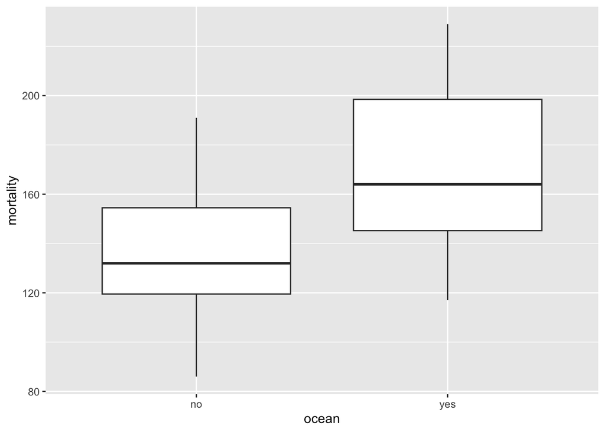

```r
library(ggplot2)
ggplot(data = USmelanoma, mapping = aes(x = ocean, y = mortality)) +
  geom_boxplot()
```

3. Fisher & van Belle present mortality figures for white adult males, aggregated on state level. If we consider the data to be a random sample from the population of ocean- and nonocean states we can apply standard statistical significance tests for location.

If we assume that normal distributions are suitable for the mortality rate within ocean- and nonocean states respectively we can use the Welch-test. This assumption is plausible as we are actually looking at an *average* of mortality per state and the Central Limit Theorem states that averages of independent & identically distributed observations tend towards normal distribution.

If the normality assumption appears dubious we can use the non-parametric U-test that tests for difference in the median of the measurement when the *shape* of the distribution in both groups is similar.

A very robust test is the so-called **median test** (which was not covered in the lecture). It specifically focusses on the median of the data. Under H<sub>0</sub>: «common median» the best estimate for the common median is the median of all data of both groups combined. Now, we can classify the data in each group relative to this common median which gives a 2x2-table where a χ<sup>2</sup>-test can be applied.

A randomizaiton test is also an alternative.

4. We perform both, the Welch test and the U-test:

```r
t.test(mortality ~ ocean, data = USmelanoma)
```

```
##
##  Welch Two Sample t-test
##
## data:  mortality by ocean
## t = -3.6, df = 39.5, p-value = 0.00089
## alternative hypothesis: true difference in means between group no and group yes is not equal to 0
## 95 percent confidence interval:
##  -49.188 -13.785
## sample estimates:
##  mean in group no mean in group yes
##            138.74            170.23
```

```r
wilcox.test(mortality ~ ocean, data = USmelanoma)
```

```
##
##  Wilcoxon rank sum test with continuity correction
##
## data:  mortality by ocean
## W = 134, p-value = 0.0011
## alternative hypothesis: true location shift is not equal to 0
```

As an addition test we implement the median test:

```r
# median test
commonMedian <- median(USmelanoma$mortality)
(medianTab <- xtabs(~ ocean + (mortality > commonMedian), data = USmelanoma))
```

```
##      mortality > commonMedian
## ocean FALSE TRUE
##   no     19    8
##   yes     6   16
```

```r
chisq.test(medianTab)
```

```
##
##  Pearson's Chi-squared test with Yates' continuity correction
##
## data:  medianTab
## X-squared = 7.37, df = 1, p-value = 0.0066
```

In the boxplot we have seen that the ocean-states show a higher mortality rate than nonocean states. All three tests yield a P-value which is way smaller than the conventional significance level of α = 5%. Hence, we speak of a statistically significant difference in mortality rate between ocean- and nonocean states. The Welch-test applies particularily to the expected value whereas the U-test (under the assumption of similar shape of distribution) and the median-test apply to the *median*.